# cdmetapopR Vignette

Reading, summarizing, customizing, and plotting CDMetaPOP outputs

# 1 Overview

This vignette shows how to use `cdmetapopR` to read, reshape, summarize, and plot CDMetaPOP outputs. The goal is to show both quick plotting functions and the lower-level data-frame outputs that can be used for custom `ggplot2` figures.

The examples use the package example output files in `inst/extdata/Adaptive_Run_08`.

The example data include:

- 2 batches
- 2 Monte Carlo replicates per batch
- `summary_popAllTime.csv`
- `summary_classAllTime.csv`
- `summary_popAllTime_DiseaseStates.csv`
- `ind0.csv` through `ind9.csv`

```r
ex_dir <- system.file("extdata", "Adaptive_Run_08", package = "cdmetapopR")

pop_file <- file.path(ex_dir, "run0batch0mc0species0", "summary_popAllTime.csv")
class_file <- file.path(ex_dir, "run0batch0mc0species0", "summary_classAllTime.csv")
ind_file <- file.path(ex_dir, "run0batch0mc0species0", "ind9.csv")

ex_dir
```

```
## [1] "C:/Users/allis/OneDrive - The Ohio State University/Research/side_projects/cdmetapop_package/cdmetapopR/inst/extdata/Adaptive_Run_08"
```

```r
list.files(ex_dir)
```

```
## [1] "run0batch0mc0species0" "run0batch0mc1species0" "run0batch1mc0species0"
## [4] "run0batch1mc1species0"
```

## 1.1 Choosing Runs, Batches, Monte Carlo Replicates, and Species

Most summary functions use the same filtering arguments:

- `run = 0`
- `batch = 0`
- `mc = 0`
- `species = 0`

These defaults intentionally select one output folder. Use `"all"` or a range of values `c(0,1)` for any of these arguments to combine multiple folders. The example directory includes two batches with two MCs each. Each of these files contains ten ind#.csvs, containing information from each year of the simulation. Additionally, each file has a summary_popAllTime.csv, summary_classAllTime.csv, and a summary_popAllTime_DiseaseStates.csv that summarizes information across the years of the simulation.

```r
one_mc <- summary_dataframe(ex_dir, type = "ind", years = 9, mc = 0)
both_mcs <- summary_dataframe(ex_dir, type = "ind", years = 9, mc = "all")
all_batches_mcs <- summary_dataframe(ex_dir, type = "pop", batch = "all", mc = "all")

c(
  one_mc_rows = nrow(one_mc),
  both_mcs_rows = nrow(both_mcs),
  all_batches_mcs_rows = nrow(all_batches_mcs)
)
```

```
##          one_mc_rows        both_mcs_rows all_batches_mcs_rows
##                  400                  800                80800
```

For individual files, `years` narrows the selected `ind##.csv` files. For summary files, years are filtered after reading by using ordinary data-frame operations.

# 2 Reading and Conversion Helpers

## 2.1 `read.cdmetapop()`

Use `read.cdmetapop()` to read a CDMetaPOP CSV file into R while keeping the CDMetaPOP-delimited columns as character columns.

```r
pop_data_chr <- read.cdmetapop(pop_file)

dim(pop_data_chr)
```

```
## [1] 200  81
```

```r
str(pop_data_chr[, 1:6])
```

```
## 'data.frame':    200 obs. of  6 variables:
##  $ Year         : chr  "0" "1" "2" "3" ...
##  $ K            : chr  "50054.54099999998|557.965|508.795|502.465|488.091|562.674|568.879|525.22|495.584|479.319|577.174|408.953|555.76"| __truncated__ "49528.29599999999|496.946|541.583|556.58|552.356|497.343|517.266|524.495|422.387|481.617|600.048|442.127|479.30"| __truncated__ "49360.182999999…
##  $ GrowthRate   : chr  "1.09496" "0.9823189888215095" "1.0098921532168093" "1.0022094564737074" ...
##  $ N_Initial    : chr  "12500|250|0|250|250|250|0|250|0|250|0|250|250|0|0|250|250|250|0|0|0|0|250|250|0|250|0|0|0|0|250|250|0|0|250|0|0"| __truncated__ "13687|312|0|296|303|326|0|310|0|309|0|180|246|0|0|306|203|254|0|0|0|0|276|327|0|297|0|0|0|0|259|258|0|0|313|0|0"| __truncated__ "13445|312|0|317…
##  $ PopSizes_Mean: chr  "0.0|nan|0.0|0.0|0.0|nan|0.0|nan|0.0|nan|0.0|0.0|nan|nan|0.0|0.0|0.0|nan|nan|nan|nan|0.0|0.0|nan|0.0|nan|nan|nan"| __truncated__ "0.0|nan|0.0|0.0|0.0|nan|0.0|nan|0.0|nan|0.0|0.0|nan|nan|0.0|0.0|0.0|nan|nan|nan|nan|0.0|0.0|nan|0.0|nan|nan|nan"| __truncated__ "0.0|nan|0.0|0.0…
##  $ PopSizes_Std : chr  "0.0|nan|0.0|0.0|0.0|nan|0.0|nan|0.0|nan|0.0|0.0|nan|nan|0.0|0.0|0.0|nan|nan|nan|nan|0.0|0.0|nan|0.0|nan|nan|nan"| __truncated__ "0.0|nan|0.0|0.0|0.0|nan|0.0|nan|0.0|nan|0.0|0.0|nan|nan|0.0|0.0|0.0|nan|nan|nan|nan|0.0|0.0|nan|0.0|nan|nan|nan"| __truncated__ "0.0|nan|0.0|0.0…
```

## 2.2 `separate_column()`

Use `separate_column()` when a CDMetaPOP column stores multiple values inside one delimited cell. The example below splits the fourth column, `N_Initial`, using `|`.

```r
n_initial_by_patch <- separate_column(pop_file, column_name = 4, sep = "|")

dim(n_initial_by_patch)
```

```
## [1] 200 102
```

```r
str(n_initial_by_patch[, 1:8])
```

```
## 'data.frame':    200 obs. of  8 variables:
##  $ V1: int  12500 13687 13445 13578 13608 13627 13612 13557 13572 13580 ...
##  $ V2: int  250 312 312 319 315 309 317 318 331 352 ...
##  $ V3: int  0 0 0 0 0 0 0 0 0 0 ...
##  $ V4: int  250 296 317 309 313 313 313 314 321 331 ...
##  $ V5: int  250 303 309 320 302 285 294 289 293 274 ...
##  $ V6: int  250 326 336 352 371 384 370 390 394 397 ...
##  $ V7: int  0 0 0 0 0 0 0 0 0 0 ...
##  $ V8: int  250 310 309 347 329 345 356 369 384 358 ...
```

## 2.3 `unite_column()`

Use `unite_column()` to combine several columns into one delimited column.

```r
small_df <- data.frame(
  Patch = c("A", "B", "C"),
  N_1 = c(25, 30, 35),
  N_2 = c(34, 44, 34)
)

unite_column(
  dataframe = small_df,
  column_name = "N_combined",
  sep = "|",
  cols = c("N_1", "N_2")
)
```

```
##   Patch N_combined
## 1     A      25|34
## 2     B      30|44
## 3     C      35|34
```

## 2.4 `create_cdmat()`

Use `create_cdmat()` to create a cost distance matrix from patch coordinates. The simplest options are Euclidean distance and equal distance.

```r
coords <- data.frame(
  x = c(0, 1, 3, 6),
  y = c(0, 2, 2, 5)
)

create_cdmat(coords, method = "euclidean")
```

```
##          1        2        3        4
## 1 0.000000 2.236068 3.605551 7.810250
## 2 2.236068 0.000000 2.000000 5.830952
## 3 3.605551 2.000000 0.000000 4.242641
## 4 7.810250 5.830952 4.242641 0.000000
```

```r
create_cdmat(coords, method = "equal")
```

```
##      [,1] [,2] [,3] [,4]
## [1,]    1    1    1    1
## [2,]    1    1    1    1
## [3,]    1    1    1    1
## [4,]    1    1    1    1
```

## 2.5 `cdmetapop_to_gene()`

Use `cdmetapop_to_gene()` to convert an `ind##.csv` file to GENEPOP or GENALEX format. The function writes the converted file to the current working directory, so this example uses a temporary directory.

```r
old_wd <- getwd()
setwd(tempdir())

cdmetapop_to_gene(ind_file, format = "genepop")
list.files(pattern = "^my_genepop")
```

```
## [1] "my_genepop_ind9.txt"
```

```r
setwd(old_wd)
```

# 3 Output Data Frames

`summary_dataframe()` returns CDMetaPOP output files as data frames for custom plotting or analysis. Use `type` to choose the file family and `run`, `batch`, `mc`, and `species` to choose which output folders to include. For `type = "pop"` and `type = "class"`, pipe-delimited summary columns are split into one row per patch or class (depending on type) by default while keeping metrics in separate columns.

```r
pop_df <- summary_dataframe(ex_dir, type = "pop", batch = 0, mc = 0)
head(pop_df[, c("Year", ".batch", ".mc", "PatchID", "GrowthRate", "K", "N_Initial")])
```

```
##   Year .batch .mc PatchID GrowthRate         K N_Initial
## 1    0      0   0       0    1.09496 50054.541     12500
## 2    0      0   0       1    1.09496   557.965       250
## 3    0      0   0       2    1.09496   508.795         0
## 4    0      0   0       3    1.09496   502.465       250
## 5    0      0   0       4    1.09496   488.091       250
## 6    0      0   0       5    1.09496   562.674       250
```

In the default long format, metrics remain in separate columns, but each pipe-delimited value is split into its own row. `PatchID` gives the position of the value inside the original `|`-delimited cell. For many `summary_popAllTime` columns, `PatchID == 0` is the total across patches (such as N_initial) and later Patch IDs are actual patch-level values.

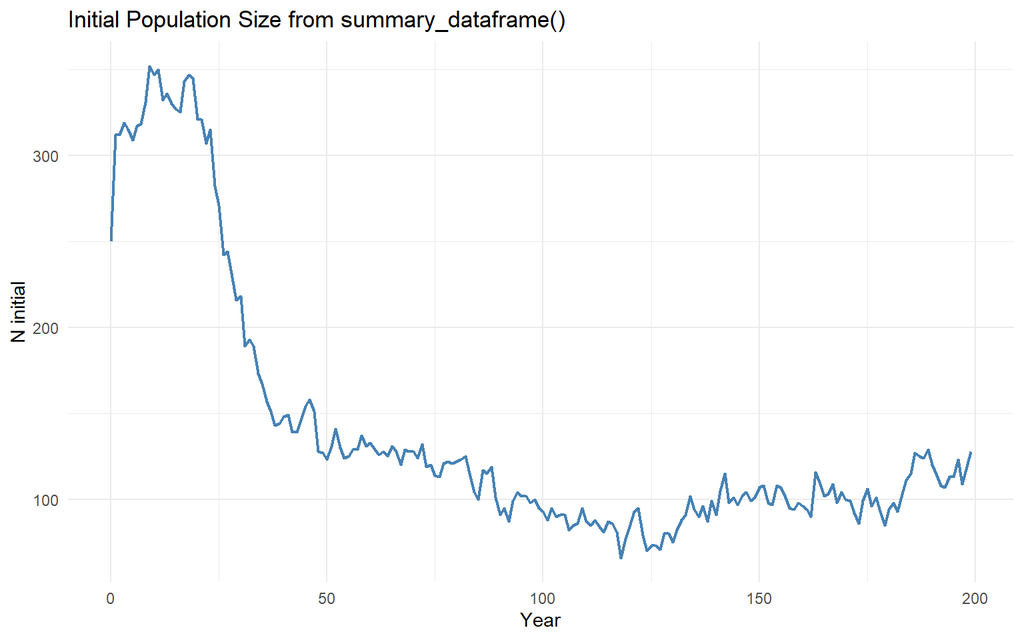

```r
pop_totals <- pop_df %>%
  filter(PatchID == 1)

ggplot(pop_totals, aes(x = Year, y = N_Initial)) +
  geom_line(linewidth = 0.8, color = "steelblue") +
  labs(
    title = "Initial Population Size from summary_dataframe()",
    x = "Year",
    y = "N initial"
  ) +
  theme_minimal()
```

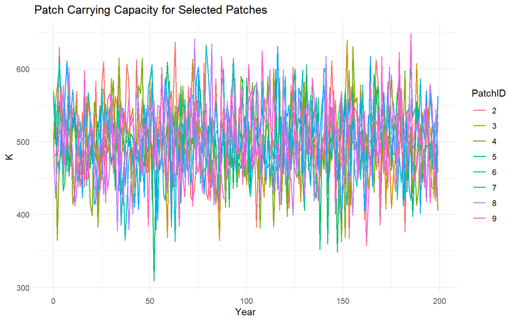

```r
patch_subset <- pop_df %>%
  filter(PatchID %in% 2:9)

ggplot(patch_subset, aes(x = Year, y = K, color = factor(PatchID))) +
  geom_line(linewidth = 0.7) +
  labs(
    title = "Patch Carrying Capacity for Selected Patches",
    x = "Year",
    y = "K",
    color = "PatchID"
  ) +
  theme_minimal()
```

The same workflow can compare Monte Carlo replicates or batches.

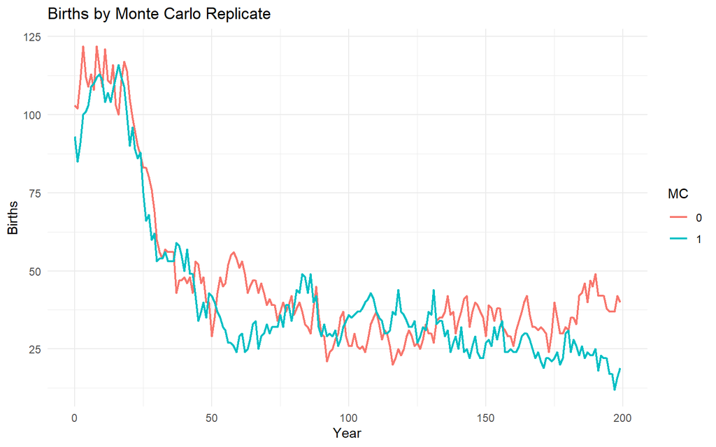

```r
pop_mc <- summary_dataframe(ex_dir, type = "pop", batch = 0, mc = "all") %>%
  filter(PatchID == 1)

ggplot(pop_mc, aes(x = Year, y = Births, color = factor(.mc), group = .mc)) +
  geom_line(linewidth = 0.8) +
  labs(
    title = "Births by Monte Carlo Replicate",
    x = "Year",
    y = "Births",
    color = "MC"
  ) +
  theme_minimal()
```

Use `summary_format = "wide"` if you need the original summary columns instead.

```r
pop_wide_df <- summary_dataframe(ex_dir, type = "pop", batch = 0, mc = 0, summary_format = "wide")
head(pop_wide_df[, c("Year", "GrowthRate", "N_Initial")])
```

```
##   Year GrowthRate
## 1    0  1.0949600
## 2    1  0.9823190
## 3    2  1.0098922
## 4    3  1.0022095
## 5    4  1.0013962
## 6    5  0.9988992
##                                                                                                                                                                                                                                                                                                          …
## 1 12500|250|0|250|250|250|0|250|0|250|0|250|250|0|0|250|250|250|0|0|0|0|250|250|0|250|0|0|0|0|250|250|0|0|250|0|0|250|0|250|250|0|250|250|0|250|250|250|0|0|250|0|0|250|0|250|250|0|250|0|250|0|250|250|0|250|0|0|0|0|250|0|0|250|0|0|0|250|250|250|250|0|0|250|250|250|0|250|250|0|250|0|250|0|250|250|0…
## 2 13687|312|0|296|303|326|0|310|0|309|0|180|246|0|0|306|203|254|0|0|0|0|276|327|0|297|0|0|0|0|259|258|0|0|313|0|0|339|0|311|224|0|250|283|0|253|245|185|0|0|266|0|0|219|0|291|247|0|207|0|249|0|339|305|0|271|0|0|0|0|294|0|0|292|0|0|0|216|247|341|314|0|0|183|286|314|0|286|199|0|360|0|317|0|225|252|0…
## 3 13445|312|0|317|309|336|0|309|0|324|0|153|231|0|0|301|168|262|0|0|0|0|273|343|0|323|0|0|0|0|262|274|0|0|324|0|0|335|0|326|224|0|246|296|0|238|243|142|0|0|245|0|0|190|0|299|245|0|190|0|229|0|346|303|0|242|0|0|0|0|295|0|0|287|0|0|0|200|236|347|325|0|0|145|286|319|0|274|172|0|366|0|316|0|197|233|0…
## 4 13578|319|0|309|320|352|0|347|0|334|0|123|238|0|0|343|165|262|0|0|0|0|274|364|0|324|0|0|0|0|282|269|0|0|340|0|0|328|0|335|207|0|224|276|0|238|233|118|0|0|261|0|0|165|0|313|230|0|184|0|236|0|364|315|0|254|0|0|0|0|327|0|0|288|0|0|0|173|225|380|336|0|0|121|300|328|0|280|159|0|393|0|327|0|174|230|0…
## 5  13608|315|0|313|302|371|0|329|0|365|0|112|240|0|0|355|150|271|0|0|0|0|280|390|0|330|0|0|0|0|301|270|0|0|352|0|0|352|0|345|202|0|210|298|0|235|251|99|0|0|250|0|0|153|0|308|217|0|178|0|217|0|398|309|0|243|0|0|0|0|290|0|0|282|0|0|0|178|219|388|358|0|0|113|314|338|0|280|136|0|394|0|330|0|158|233|0…
## 6  13627|309|0|313|285|384|0|345|0|391|0|102|245|0|0|347|147|267|0|0|0|0|278|402|0|305|0|0|0|0|310|276|0|0|369|0|0|366|0|329|207|0|217|304|0|223|253|85|0|0|233|0|0|127|0|311|218|0|168|0|234|0|420|297|0|265|0|0|0|0|298|0|0|296|0|0|0|178|216|388|359|0|0|106|306|345|0|280|127|0|394|0|344|0|161|215|0…
```

```r
class_df <- summary_dataframe(ex_dir, type = "class", batch = 0, mc = 0)
head(class_df[, c("Year", ".batch", ".mc", "ClassID", "Ages", "N_Initial_Age")])
```

```
##   Year .batch .mc ClassID Ages N_Initial_Age
## 1    0      0   0       1    0          2442
## 2    0      0   0       2    1          1919
## 3    0      0   0       3    2          1628
## 4    0      0   0       4    3          1337
## 5    0      0   0       5    4          1103
## 6    0      0   0       6    5           848
```

Class summaries are useful when the class ID positions correspond to age or size classes.

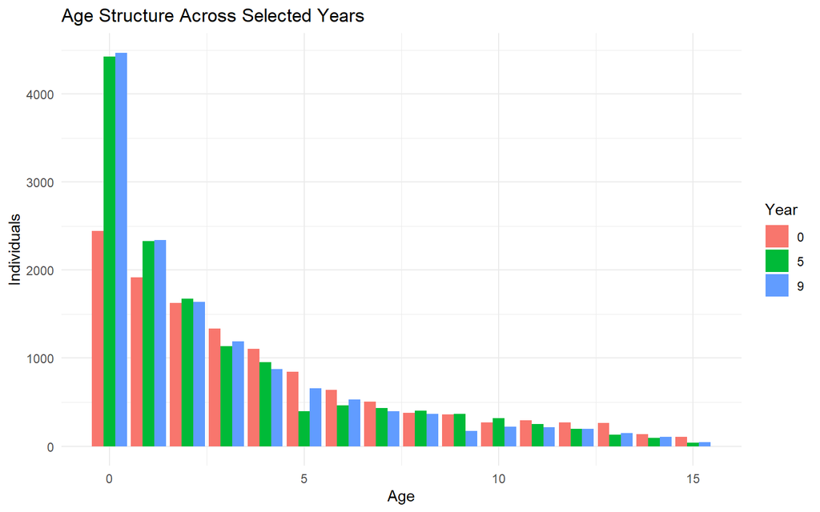

```r
class_selected_years <- class_df %>%
  filter(Year %in% c(0, 5, 9))

ggplot(class_selected_years, aes(x = Ages, y = N_Initial_Age, fill = factor(Year))) +
  geom_col(position = "dodge") +
  labs(
    title = "Age Structure Across Selected Years",
    x = "Age",
    y = "Individuals",
    fill = "Year"
  ) +
  theme_minimal()
```

Disease-state files are returned in tidy long format by default, with one row per year, source, and disease state.

```r
disease_df <- summary_dataframe(
  ex_dir,
  type = "disease",
  state_names = c("Susceptible", "Infected", "Recovered")
)
head(disease_df)
```

```
## # A tibble: 6 × 15
##    Year   Run Batch    MC Species Source   .source_file .source_group .source_id
##   <dbl> <int> <int> <int>   <int> <chr>    <chr>        <chr>         <chr>
## 1     0     0     0     0       0 Adaptiv… C:/Users/al… Adaptive_Run… run0batch…
## 2     0     0     0     0       0 Adaptiv… C:/Users/al… Adaptive_Run… run0batch…
## 3     0     0     0     0       0 Adaptiv… C:/Users/al… Adaptive_Run… run0batch…
## 4     1     0     0     0       0 Adaptiv… C:/Users/al… Adaptive_Run… run0batch…
## 5     1     0     0     0       0 Adaptiv… C:/Users/al… Adaptive_Run… run0batch…
## 6     1     0     0     0       0 Adaptiv… C:/Users/al… Adaptive_Run… run0batch…
## # ℹ 6 more variables: .run <int>, .batch <int>, .mc <int>, .species <int>,
## #   State <fct>, Count <dbl>
```

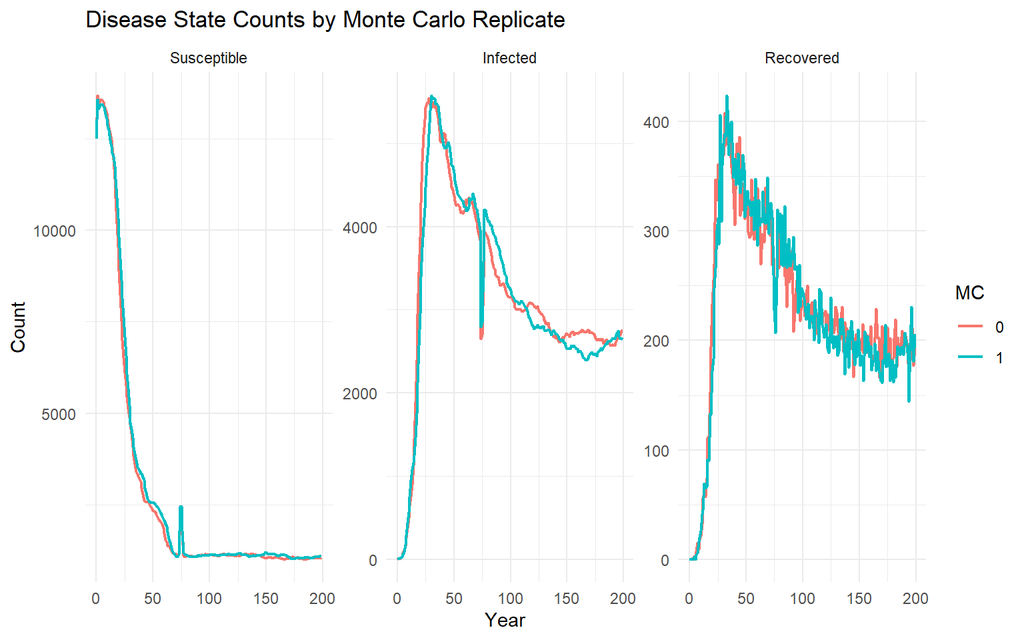

```r
disease_mc <- summary_dataframe(
  ex_dir,
  type = "disease",
  state_names = c("Susceptible", "Infected", "Recovered"),
  mc = "all"
)

ggplot(disease_mc, aes(x = Year, y = Count, color = factor(.mc), group = .mc)) +
  geom_line(linewidth = 0.8) +
  facet_wrap(~ State, scales = "free_y") +
  labs(
    title = "Disease State Counts by Monte Carlo Replicate",
    x = "Year",
    y = "Count",
    color = "MC"
  ) +
  theme_minimal()
```

Individual files can be filtered by year and patch.

```r
ind_df <- summary_dataframe(ex_dir, type = "ind", years = 9, patches = c(1, 3))
head(ind_df)
```

```
##   PatchID   XCOORD   YCOORD                          ID
## 1       1 56758.45 381341.8     S1_F10_m1f1_P10_Y8_UO17
## 2       1 56758.45 381341.8    S1_F33_m1f1_P33_Y8_UO111
## 3       1 56758.45 381341.8     S1_F44_m1f1_P44_Y8_UO71
## 4       1 56758.45 381341.8   ID1_F10_m9f9_P44_Y7_UO598
## 5       1 56758.45 381341.8    I1_F44_m9f9_P10_Y6_UO626
## 6       1 56758.45 381341.8 I1_F10_m77f77_P10_Y5_UO3306
##                            MID                         FID sex age size mature
## 1     I1_F33_m9f9_P44_Y6_UO582   ID1_F18_m9f9_P33_Y4_UO548 MXY   1    0      0
## 2    I1_F10_m-1f-1_P1_Y-1_U180 I1_F44_m77f77_P10_Y2_UO3381 MXY   1    0      0
## 3  I1_F33_m77f77_P33_Y4_UO3297    I1_F10_m9f9_P33_Y5_UO537 MXY   1    0      0
## 4     I9_F44_m9f9_P10_Y4_UO567 I9_F33_m77f77_P10_Y4_UO3281 MXY   2    0      1
## 5     I9_F33_m9f9_P10_Y0_UO504    I9_F10_m-1f-1_P9_Y-1_U99 FXX   3    0      1
## 6 ID77_F82_m-1f-1_P77_Y-1_U164    I77_F10_m1f1_P33_Y3_UO25 FXX   4    0      1
##   newmature layeggs capture recapture state CDist  Hindex Species ClassFile
```

[output cut: 34 more lines]

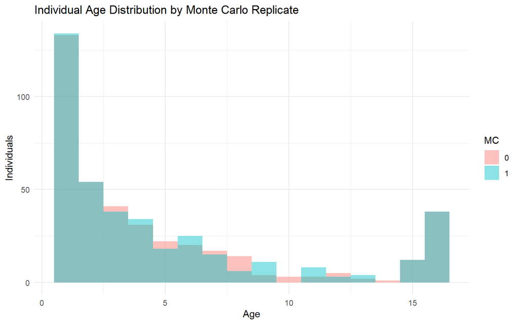

```r
ind_year9 <- summary_dataframe(ex_dir, type = "ind", years = 9, mc = "all")

ggplot(ind_year9, aes(x = age, fill = factor(.mc))) +
  geom_histogram(binwidth = 1, position = "identity", alpha = 0.45) +
  labs(
    title = "Individual Age Distribution by Monte Carlo Replicate",
    x = "Age",
    y = "Individuals",
    fill = "MC"
  ) +
  theme_minimal()
```

You may also examine sizes of individuals, however this does not vary in our example files:

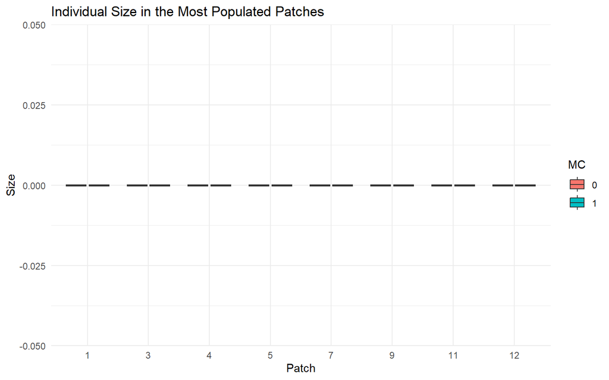

```r
top_patches <- ind_year9 %>%
  count(PatchID, sort = TRUE) %>%
  slice_head(n = 8) %>%
  pull(PatchID)

ind_top_patches <- ind_year9 %>%
  filter(PatchID %in% top_patches)

ggplot(ind_top_patches, aes(x = factor(PatchID), y = size, fill = factor(.mc))) +
  geom_boxplot(outlier.alpha = 0.3) +
  labs(
    title = "Individual Size in the Most Populated Patches",
    x = "Patch",
    y = "Size",
    fill = "MC"
  ) +
  theme_minimal()
```

Perhaps view the distribution of individuals spatially:

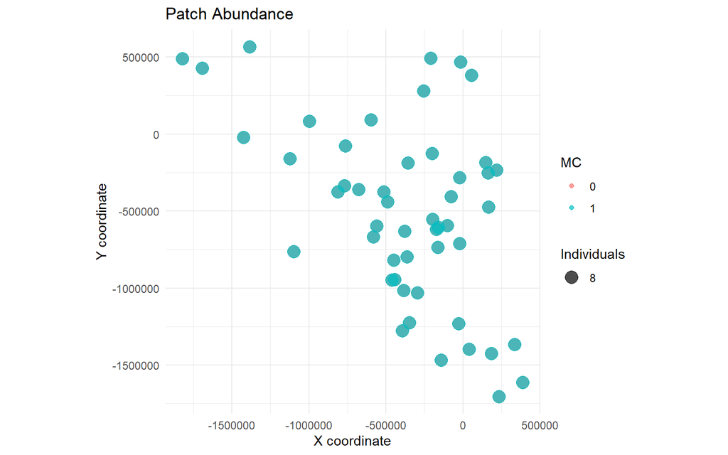

```r
patch_counts <- ind_year9 %>%
  group_by(.mc, PatchID, XCOORD, YCOORD) %>%
  summarise(n = n(), .groups = "drop")

ggplot(patch_counts, aes(x = XCOORD, y = YCOORD, size = n, color = factor(.mc))) +
  geom_point(alpha = 0.7) +
  coord_equal() +
  labs(
    title = "Patch Abundance",
    x = "X coordinate",
    y = "Y coordinate",
    size = "Individuals",
    color = "MC"
  ) +
  theme_minimal()
```

# 4 Population Summary Plots

If users prefer to view figures that can be made directly from CDMetaPOP outputs, they can use the following summary_pop() functions.

`summary_pop()` works with `summary_popAllTime.csv` files. The input can be a single file, a vector of files, a data frame, or a directory containing CDMetaPOP output folders.

When a directory is supplied, `summary_pop()` discovers the matching output folders. By default it uses `run = 0`, `batch = 0`, `mc = 0`, and `species = 0`; use `"all"` for any of those arguments to include multiple runs, batches, Monte Carlo replicates, or species.

## 4.1 Initial Population Size

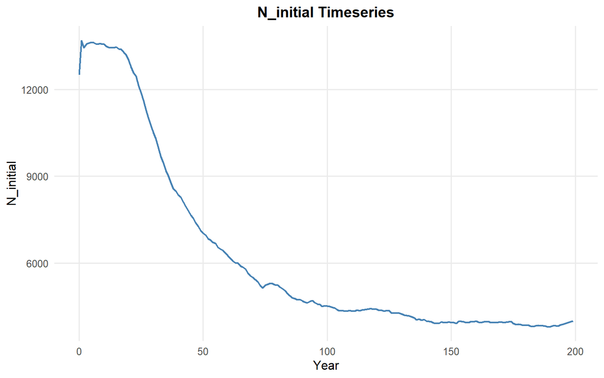

```r
summary_pop(ex_dir, type = "N_initial")
```

Include multiple Monte Carlo replicates by setting `mc = "all"`. With multiple source files, the default behavior can show individual MC trajectories and a summary band.

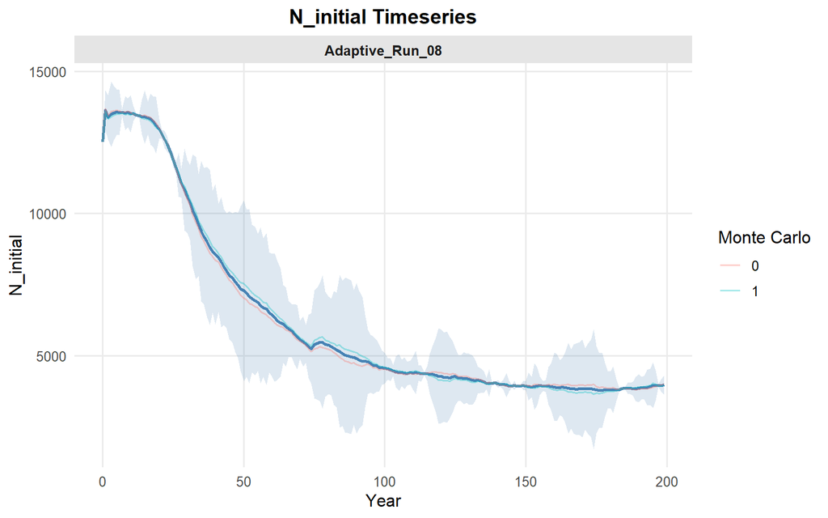

```r
summary_pop(ex_dir, type = "N_initial", mc = "all")
```

To show only the summarized pattern, set `show_mc = FALSE`.

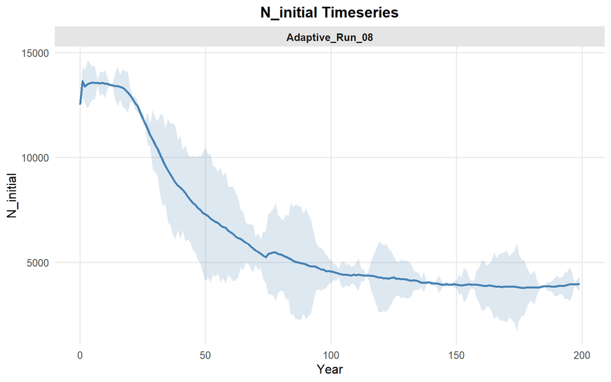

```r
summary_pop(ex_dir, type = "N_initial", mc = "all", show_mc = FALSE)
```

## 4.2 Sex Counts

By default, `type = "sex"` shows males and females only.

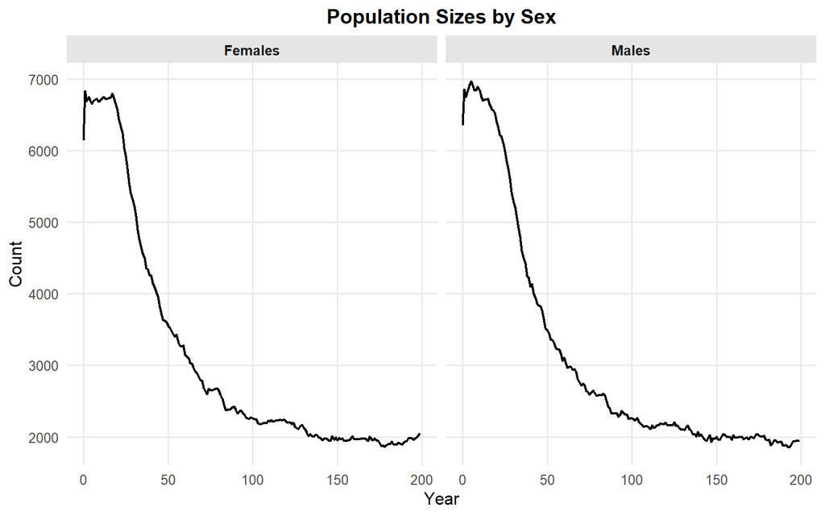

```r
summary_pop(ex_dir, type = "sex")
```

Use `include_yys = TRUE` to include YY males and YY females. This may be relevant for fisheries research.

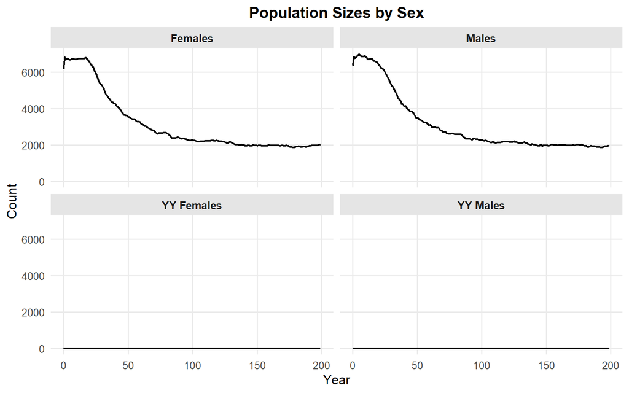

```r
summary_pop(ex_dir, type = "sex", include_yys = TRUE)
```

The same YY option works when comparing multiple batches or MCs.

```r
summary_pop(
  ex_dir,
  type = "sex",
  batch = "all",
  mc = "all",
  include_yys = TRUE,
  show_mc = FALSE
)
```

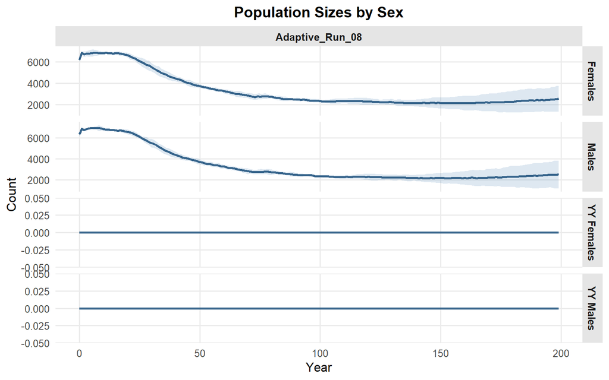

## 4.3 Mature Counts

By default, `type = "mature"` shows mature males and mature females only.

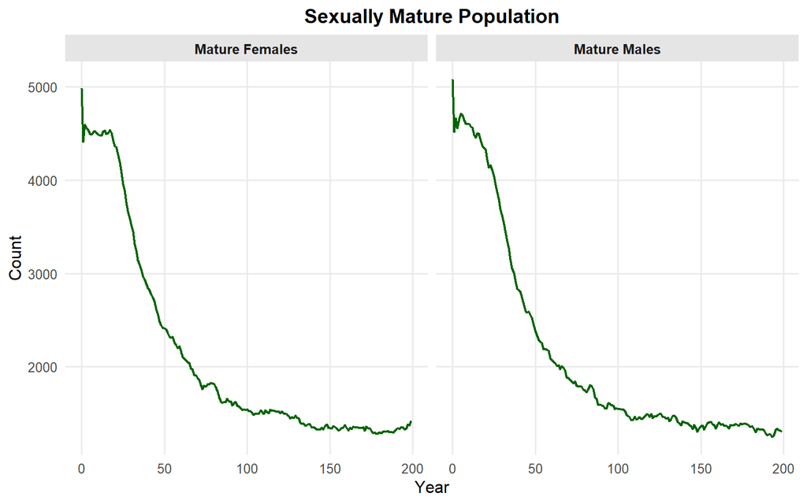

```r
summary_pop(ex_dir, type = "mature")
```

Use `include_yys = TRUE` to include mature YY males and mature YY females.

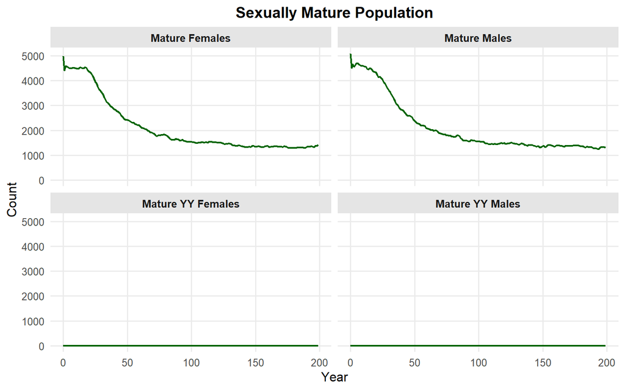

```r
summary_pop(ex_dir, type = "mature", include_yys = TRUE)
```

## 4.4 Births

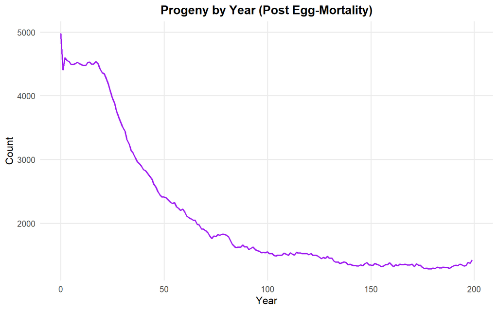

```r
summary_pop(ex_dir, type = "births")
```

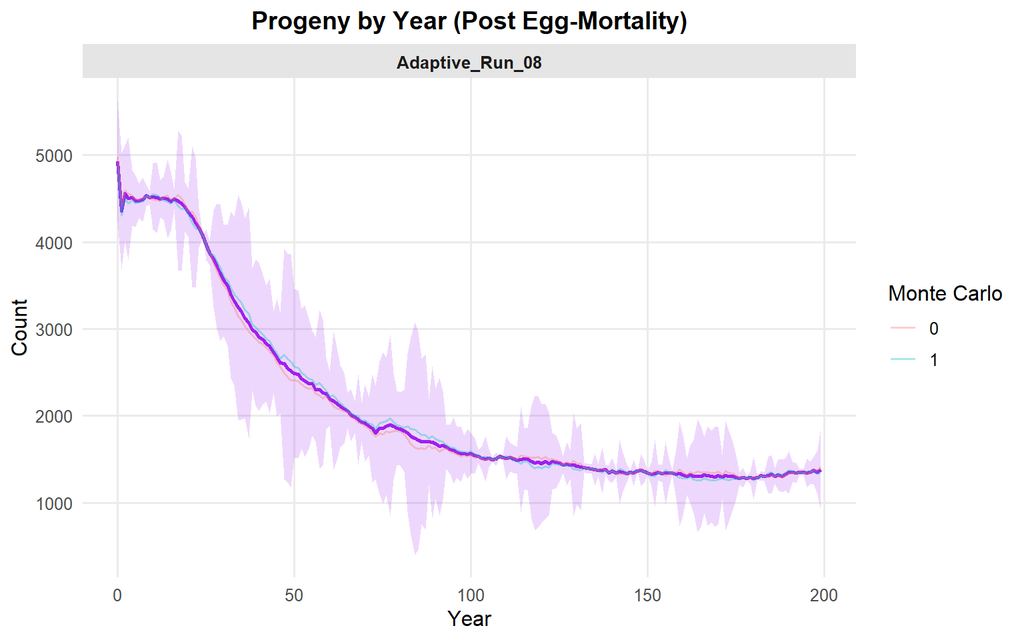

```r
summary_pop(ex_dir, type = "births", mc = "all")
```

## 4.5 Myy Ratio

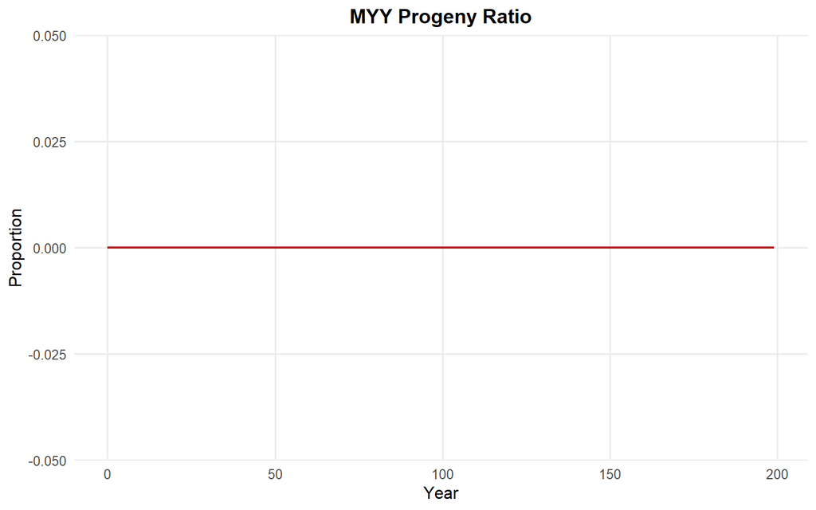

```r
summary_pop(ex_dir, type = "myy_ratio")
```

## 4.6 Patch Abundance from `summary_popAllTime.csv`

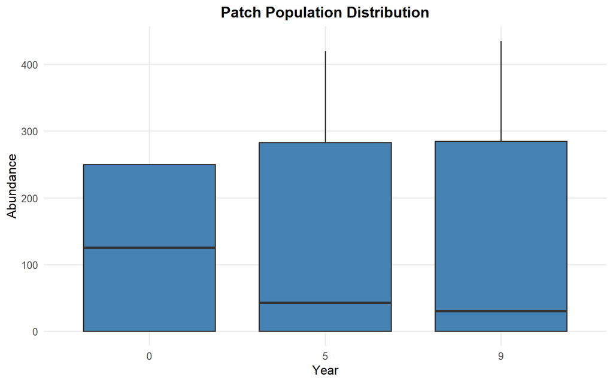

```r
summary_pop(ex_dir, type = "patch", years = c(0, 5, 9))
```

## 4.7 Allelic Richness and Heterozygosity from `summary_popAllTime.csv`

These options summarize genetic metrics stored in the population summary file.

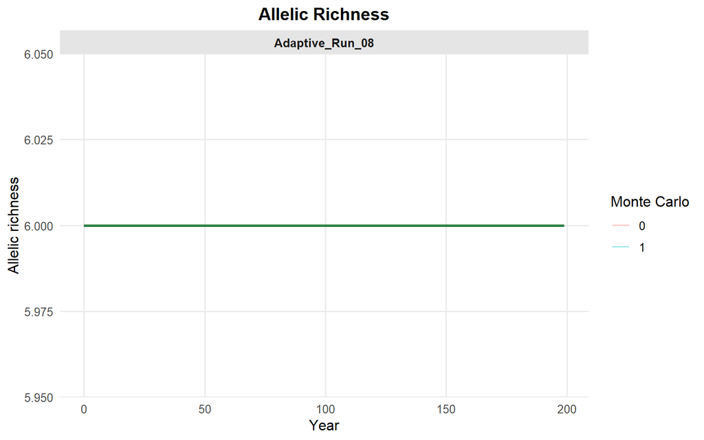

```r
summary_pop(ex_dir, type = "allelic_richness", mc = "all")
```

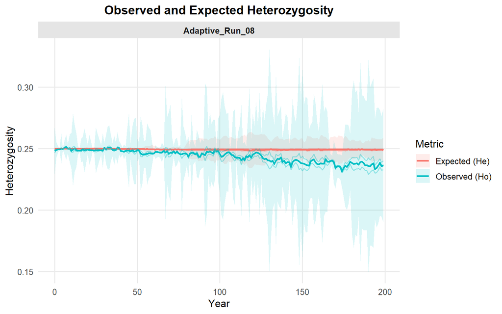

```r
summary_pop(ex_dir, type = "het", mc = "all")
```

# 5 Class Summary Plots

`summary_class()` works with `summary_classAllTime.csv` files.

## 5.1 Age Class Counts

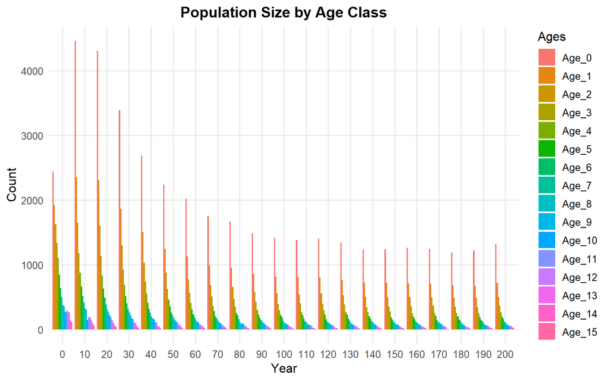

```r
summary_class(ex_dir, type = "age_class", n = 10)
```

Use a smaller `n` to facet more years. This can be useful for short example runs or simulations with relatively few generations.

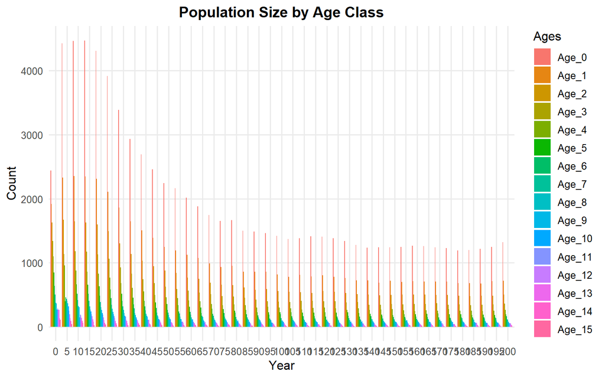

```r
summary_class(ex_dir, type = "age_class", n = 5)
```

## 5.2 Age Plus One

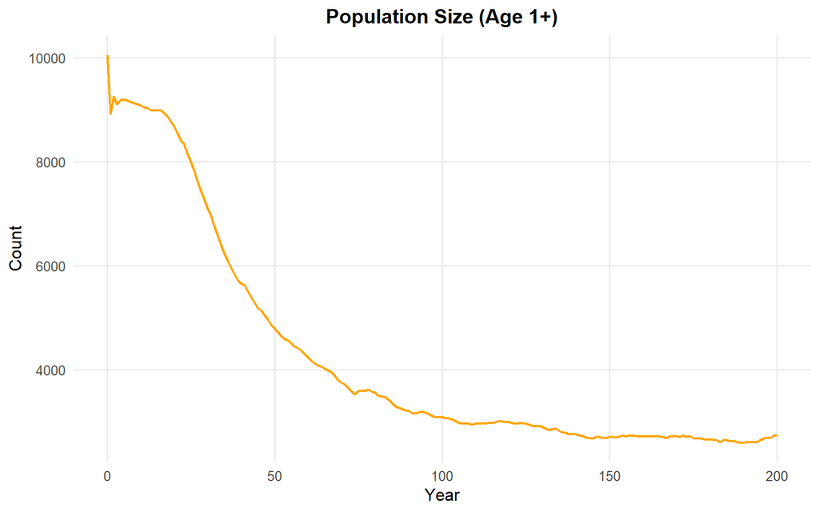

```r
summary_class(ex_dir, type = "age_plus_one")
```

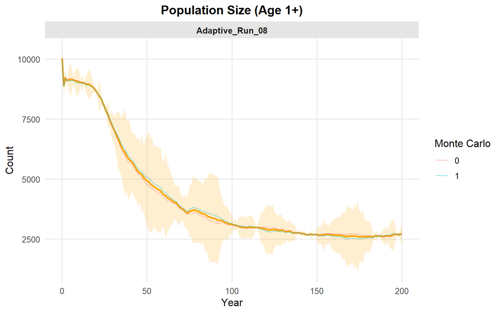

```r
summary_class(ex_dir, type = "age_plus_one", mc = "all")
```

# 6 Disease State Summaries

`summarize_states()` works with `summary_popAllTime_DiseaseStates.csv` files. It summarizes disease-state counts across Monte Carlo replicates and compares batches.

## 6.1 Default State Names

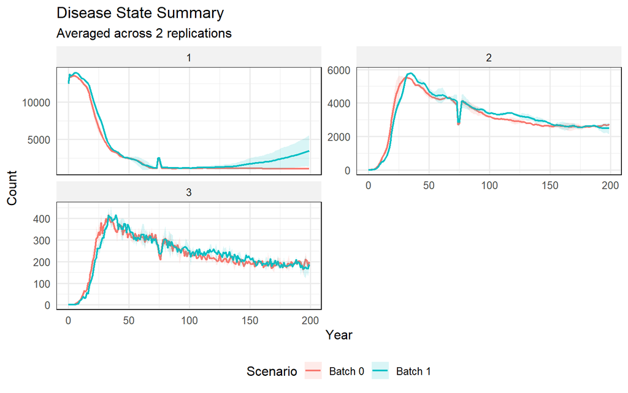

```r
summarize_states(ex_dir)
```

## 6.2 Custom State and Scenario Names

```r
summarize_states(
  ex_dir,
  state_names = c("State 1", "State 2", "State 3"),
  scenario_names = c("Batch 0", "Batch 1")
)
```

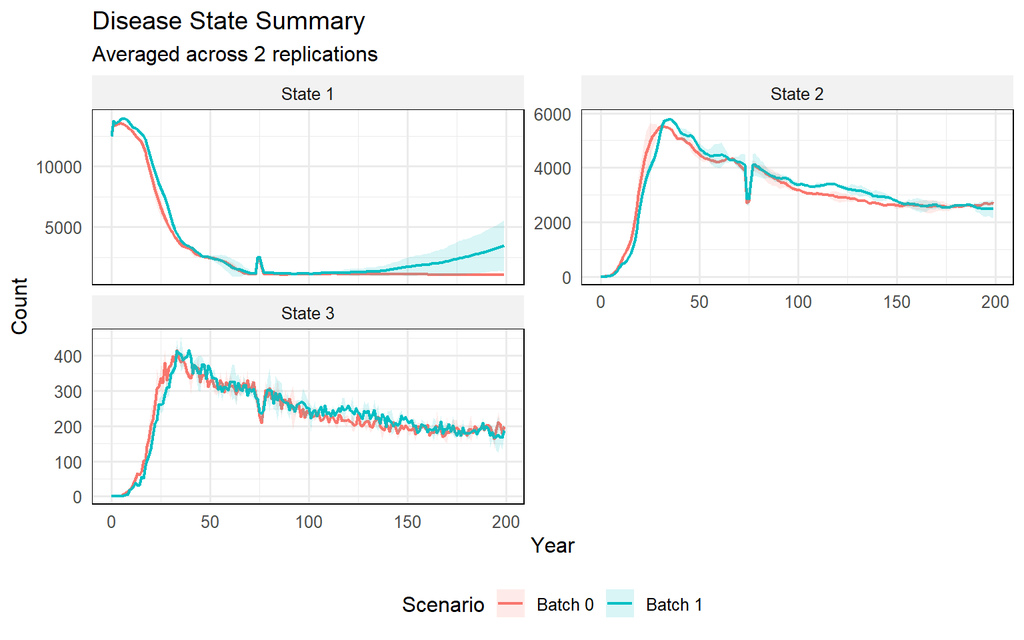

## 6.3 Cumulative State

Use `cumulative_states` for a state that should be plotted as a running total within each Monte Carlo replicate.

```r
summarize_states(
  ex_dir,
  state_names = c("State 1", "State 2", "State 3"),
  scenario_names = c("Batch 0", "Batch 1"),
  cumulative_states = "State 3"
)
```

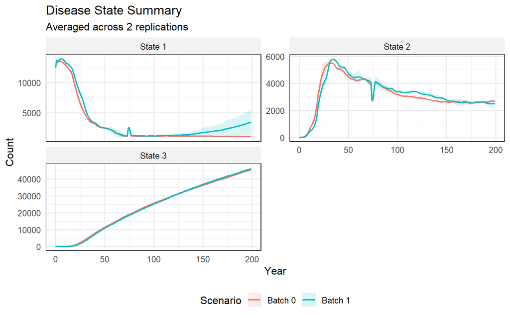

# 7 Individual File Summaries

`summary_ind()` works with `ind##.csv` files. The input can be one file, multiple files, a run folder, a top-level output directory, or a data frame.

For one-year plots, specify `year`. For movement over time, specify `years`.

## 7.1 Age Histogram

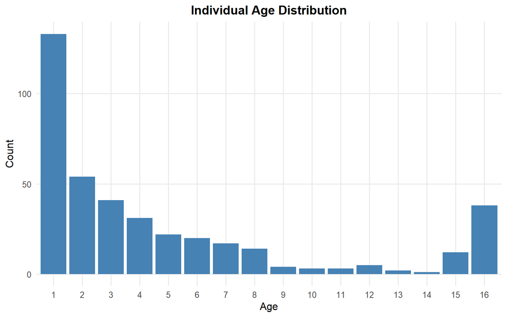

```r
summary_ind(ex_dir, type = "age", year = 9, batch = 0, mc = 0)
```

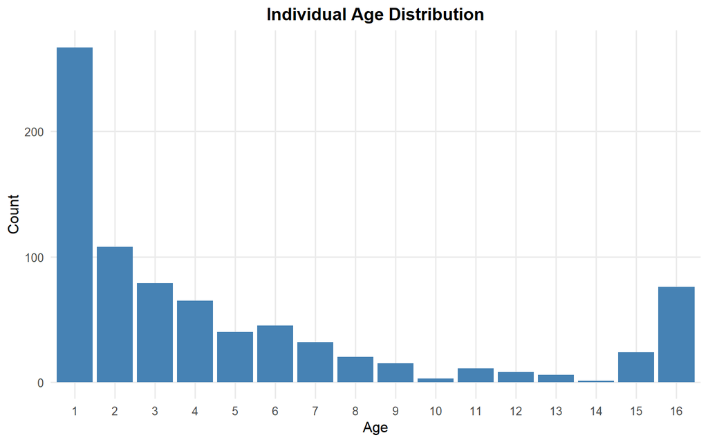

```r
summary_ind(ex_dir, type = "age", year = 9, batch = 0, mc = "all")
```